# DA410_Project7_MattGraham

Exploratory Factor Analysis

```r
library(nnspat)  # used for dist2full()
library("dplyr")  # used to select numeric datatypes
library("ggplot2")
library(reshape)  # used for melting matricies
library(klaR)
library(ggvis)
library(class)
library(gmodels)
library(MASS)
library(readxl)
library(psych)
library(corrplot)
```

Get data

```r
subject <- read.csv("subject.csv", header=TRUE)
subject
```

| BIO | GEO | CHEM | ALG | CALC | STAT |
| --- | --- | --- | --- | --- | --- |
| 1 | 1 | 1 | 1 | 1 | 1 |
| 4 | 4 | 3 | 4 | 4 | 4 |
| 2 | 1 | 3 | 4 | 1 | 1 |
| 2 | 3 | 2 | 4 | 4 | 3 |
| 3 | 1 | 2 | 2 | 3 | 4 |
| 1 | 1 | 1 | 4 | 4 | 4 |
| 3 | 3 | 3 | 2 | 3 | 1 |
| 4 | 3 | 4 | 2 | 3 | 2 |
| 2 | 1 | 3 | 3 | 4 | 3 |
| 2 | 3 | 3 | 2 | 3 | 4 |

[output cut: 290 more lines]

Assumption check:

Variables used should be metric. Dummy variables can also be considered, but only in special cases. -> check

Sample size: Sample size should be more than 200. -> check

Homogeneous sample: A sample should be homogenous. Violation of this assumption increases the sample size as the number of variables increases. Reliability analysis is conducted to check the homogeneity between variables.

Correlation: At least 0.30 correlations are required between the research variables.

```r
subject.cor <- cor(subject)
as.data.frame(subject.cor)
```

|  | BIO | GEO | CHEM | ALG | CALC | STAT |
| --- | --- | --- | --- | --- | --- | --- |
| BIO | 1.0000000 | 0.6822208 | 0.7470278 | 0.1153204 | 0.2134271 | 0.2028315 |
| GEO | 0.6822208 | 1.0000000 | 0.6814857 | 0.1353557 | 0.2045215 | 0.2316288 |
| CHEM | 0.7470278 | 0.6814857 | 1.0000000 | 0.0838225 | 0.1364251 | 0.1659747 |
| ALG | 0.1153204 | 0.1353557 | 0.0838225 | 1.0000000 | 0.7709303 | 0.4094324 |
| CALC | 0.2134271 | 0.2045215 | 0.1364251 | 0.7709303 | 1.0000000 | 0.5073147 |
| STAT | 0.2028315 | 0.2316288 | 0.1659747 | 0.4094324 | 0.5073147 | 1.0000000 |

We have a few correlations that are unable to be compared, and will be noted through analysis

There should be no outliers in the data.

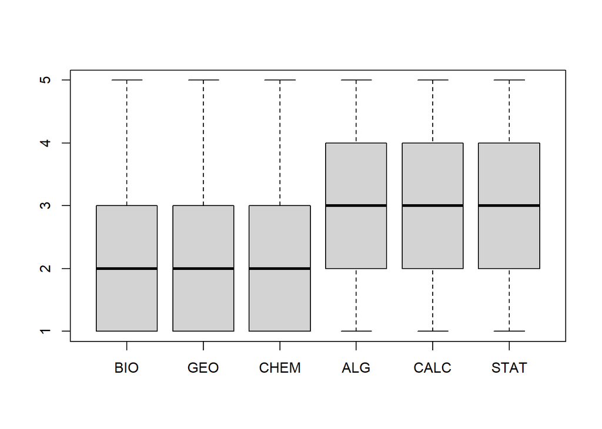

```r
boxplot(subject)
```

There are no outliers

### Running fa

```r
solution <- fa(r = subject.cor, nfactors = 2, rotate = "oblimin", fm="pa")
solution
```

```
## Factor Analysis using method =  pa
## Call: fa(r = subject.cor, nfactors = 2, rotate = "oblimin", fm = "pa")
## Standardized loadings (pattern matrix) based upon correlation matrix
##       PA1   PA2   h2    u2 com
## BIO  0.76 -0.42 0.75 0.255 1.6
## GEO  0.71 -0.36 0.63 0.369 1.5
## CHEM 0.72 -0.47 0.75 0.253 1.7
## ALG  0.51  0.62 0.65 0.354 1.9
## CALC 0.65  0.70 0.92 0.081 2.0
## STAT 0.45  0.30 0.29 0.709 1.8
##
##                        PA1  PA2
## SS loadings           2.48 1.50
## Proportion Var        0.41 0.25
## Cumulative Var        0.41 0.66
## Proportion Explained  0.62 0.38
## Cumulative Proportion 0.62 1.00
##
## Mean item complexity =  1.7
## Test of the hypothesis that 2 factors are sufficient.
##
## The degrees of freedom for the null model are  15  and the objective function was  2.87
## The degrees of freedom for the model are 4  and the objective function was  0.01
##
## The root mean square of the residuals (RMSR) is  0.01
## The df corrected root mean square of the residuals is  0.02
##
## Fit based upon off diagonal values = 1
## Measures of factor score adequacy
##                                                    PA1  PA2
## Correlation of (regression) scores with factors   0.96 0.94
## Multiple R square of scores with factors          0.91 0.89
## Minimum correlation of possible factor scores     0.83 0.79
```